# Body Weight – Simple Linear Regression

#### Background

Do individuals that engage in regular exercise know and report their true weight? Reported weights and actual weights were collected from 200 regularly exercising individuals in order to answer this question (as well as other questions). A mixture of males and females were included in the data. One outlier was removed, observation number 12, due to their body weight being dramatically heavier that the other 199 observations. The reported weight for this individual was one third of their actual weight, thus either an error in reporting or calculation seems likely.

#### Analysis

The hypotheses for our study concern the slope. If the slope is zero, then there is not a meaningful relationship between the expected weight and the reported weight of individuals.

$$H_0: \beta_1 = 0$$
$$H_a: \beta_1 \neq 0$$

A scatterplot of the relationship between weight and reported weights shows a strong positive trend.

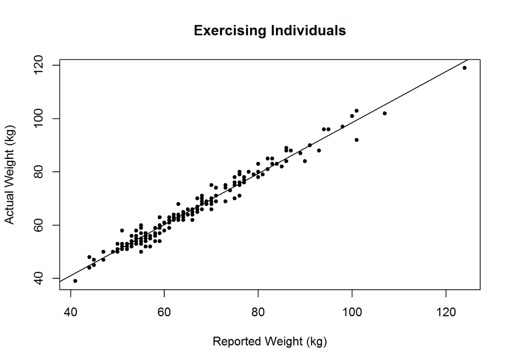

A t test of the previously stated hypotheses about the slope shows the slope is significantly different from zero $(p<0.001)$.

#### Interpretation

The estimated value of the slope is 0.958 which shows that on average, individuals weigh just a little less than what they reported. More specifically, we expect individuals to weigh 0.958 times what they reported. A 95% confidence interval for the true slope is (0.9344139, 0.9823347) which is useful for demonstrating that the value of 1 is not in the interval. Note that a value of 1 would imply that people perfectly reported their weight.

##### Appropriateness of the above Regression

It is arguable whether or not the above analysis is appropriate. As shown by the residuals versus fitted values plot, there are some odd patterns visible which are due to the integer values of the data. This is okay. The linearity is somewhat questionable, but not too bad. The constant variance assumption does not appear to be violated. The Normal Q-Q plot shows there is some question surrounding the normality of the residuals. However, the evidence is not overwhelming enough to discredit the above analysis. The error terms do not appear to be correlated.

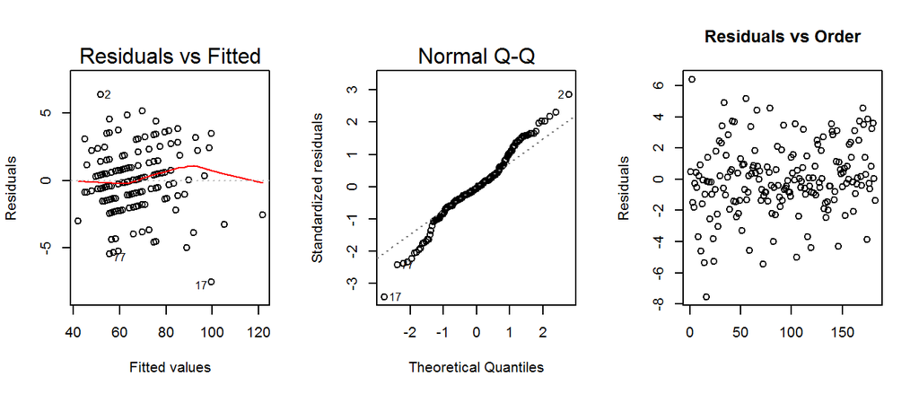